# 03_InitialDataVisualization

J. M. Rodríguez

2023-06-19

## Initial setup

This document is meant to visualize the variety of different ways of handling the data for the estimation of parameters. It will be using Harvard forest as a baseline.

| Mnemonic | Latin | n_stem | n_genet | perc_Stems | perc_Alive |
| --- | --- | --- | --- | --- | --- |
|  | All stems | 81108 | 67450 | NA | 84.2 |
| tsugca | Tsuga canadensis | 27719 | 26104 | 34.2 | 85.0 |
| acerru | Acer rubrum | 12168 | 9169 | 15.0 | 87.9 |
| kalmla | Kalmia latifolia | 5594 | 4073 | 6.9 | 91.5 |
| fagugr | Fagus grandifolia | 5133 | 4457 | 6.3 | 81.6 |
| betual | Betula alleghaniensis | 4868 | 3985 | 6.0 | 87.4 |
| querru | Quercus rubra | 4703 | 3952 | 5.8 | 90.2 |
| hamavi | Hamamelis virginiana | 3658 | 1818 | 4.5 | 79.1 |
| pinust | Pinus strobus | 2727 | 2689 | 3.4 | 66.1 |
| vaccco | Vaccinium corymbosum | 2025 | 1144 | 2.5 | 82.8 |
| vibunu | Viburnum nudum | 1769 | 934 | 2.2 | 98.8 |
| betule | Betula lenta | 1616 | 1481 | 2.0 | 88.9 |
| piceab | Picea abies | 1500 | 1459 | 1.8 | 60.7 |
| ilexve | Ilex verticillata | 1317 | 861 | 1.6 | 75.2 |
| castde | Castanea dentata | 1180 | 842 | 1.5 | 71.6 |
| pinure | Pinus resinosa | 970 | 970 | 1.2 | 81.0 |
| betupa | Betula papyrifera | 761 | 688 | 0.9 | 74.9 |
| acerpe | Acer pensylvanicum | 630 | 499 | 0.8 | 67.3 |
| amella | Amelanchier laevis | 393 | 332 | 0.5 | 84.5 |
| prunse | Prunus serotina | 390 | 354 | 0.5 | 64.9 |
| ilexmu | Ilex mucronata | 241 | 193 | 0.3 | 75.9 |
| vibula | Viburnum lantanoides | 231 | 188 | 0.3 | 38.1 |
| querve | Quercus velutina | 221 | 192 | 0.3 | 94.1 |
| fraxam | Fraxinus americana | 212 | 194 | 0.3 | 84.9 |
| rhodpr | Rhododendron prinophyllum | 159 | 92 | 0.2 | 81.8 |
| nysssy | Nyssa sylvatica | 156 | 145 | 0.2 | 98.7 |
| piceru | Picea rubens | 144 | 138 | 0.2 | 79.9 |
| betupo | Betula populifolia | 129 | 110 | 0.2 | 78.3 |
| lindbe | Lindera benzoin | 124 | 72 | 0.2 | 66.1 |
| sorbam | Sorbus americana | 88 | 74 | 0.1 | 85.2 |
| lyonli | Lyonia ligustrina | 56 | 45 | 0.1 | 53.6 |
| queral | Quercus alba | 48 | 45 | 0.1 | 83.3 |
| vibude | Viburnum dentatum | 48 | 37 | 0.1 | 97.9 |
| fraxni | Fraxinus nigra | 43 | 42 | 0.1 | 86.0 |
| ostrvi | Ostrya virginiana | 28 | 26 | 0.0 | 92.9 |
| prunpe | Prunus pensylvanica | 28 | 26 | 0.0 | 42.9 |
| ilexla | Ilex laevigata | 10 | 7 | 0.0 | 50.0 |
| alnuin | Alnus incana | 6 | 2 | 0.0 | 33.3 |
| acersa | Acer saccharum | 4 | 2 | 0.0 | 75.0 |
| sambra | Sambucus racemosa | 4 | 2 | 0.0 | 100.0 |
| popugr | Populus grandidentata | 2 | 2 | 0.0 | 100.0 |
| poputr | Populus tremuloides | 2 | 2 | 0.0 | 50.0 |
| franal | Frangula alnus | 1 | 1 | 0.0 | 0.0 |
| ulmuam | Ulmus americana | 1 | 1 | 0.0 | 100.0 |
| vibuac | Viburnum acerfolium | 1 | 1 | 0.0 | 100.0 |

### Canopy Levels

| CanopyLvl | n_stem | n_genet | perc_Total |
| --- | --- | --- | --- |
| 1 | 16708 | 14657 | 20.6 |
| 2 | 36715 | 30905 | 45.3 |
| 3 | 13693 | 12100 | 16.9 |
| 4 | 1144 | 1045 | 1.4 |
| NA | 12848 | 11786 | 15.8 |

### Stature data

Stature here follows the same calculation as in Kambach et al. 2022, arithmetic mean of the largest 6 stem diameter measurements across the OTU. Each StemID can only be included once (if the largest individual lives across multiple censuses, it will only have one, its largest, DBH included)

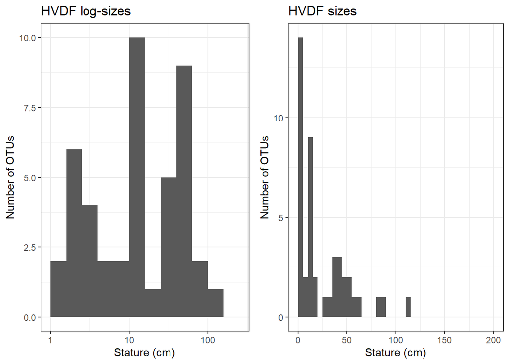

The big point of concern here are the few number of stems for the last canopy level (not including NA). Some cutoff needs to be chosen to be shared across sites, two options are that the canopy level must have a minimum of a 1000 stems, or at a minimum must represent 5% of all stems.

### Growth Rates

There are several ways to calculate growth rates using these data. Option 1 uses the same expression as in Grady et al. Unpublished. It takes the two measurement points, takes a point estimate of an exponential growth rate, then infers the diameter at 2 years and 3 years after the first measurement and takes their difference.
$$g_1 = d_i* \left(\left( \frac{d_f}{d_i} \right)^{3yr/\Delta t} - \left(
\frac{d_f}{d_i} \right)^{2yr/\Delta t}\right)$$
Where $d_i$ and $d_f$ represent the initial and final diameters measurements respectively. $\Delta t$ is the duration of time between the two measurements, and $g_1$ is the amount of growth (henceforth referred to as growth-1) in cm. Here values can take on any real number.

The next format simply is the exponential growth rate point estimate (referred to as growth-2). And is calculated as:
$$g_2 = \left( \frac{d_f}{d_i} \right)^{1/\Delta t}$$
Where $g_2$ is the growth-2 rate in the format of a proportion, with 1 being no growth.

Lastly, growth-3 follows the calculation used by Kambach et al. for a simple linear calculation.

$$g_3 = \frac{d_f - d_i}{\Delta t}$$
Where $g_3$ is the growth rate in cm/yr, and all other symbols follow the other methods.

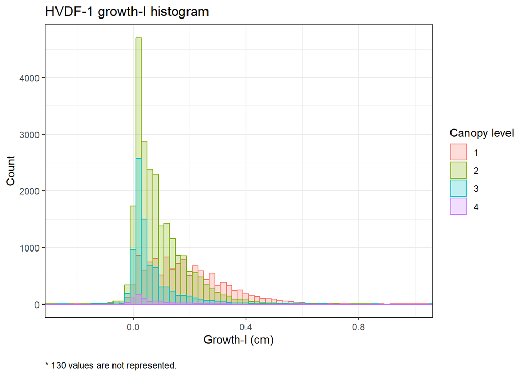

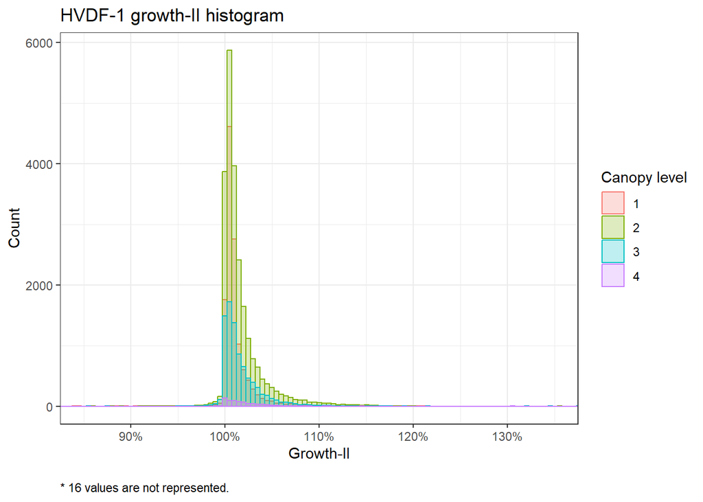

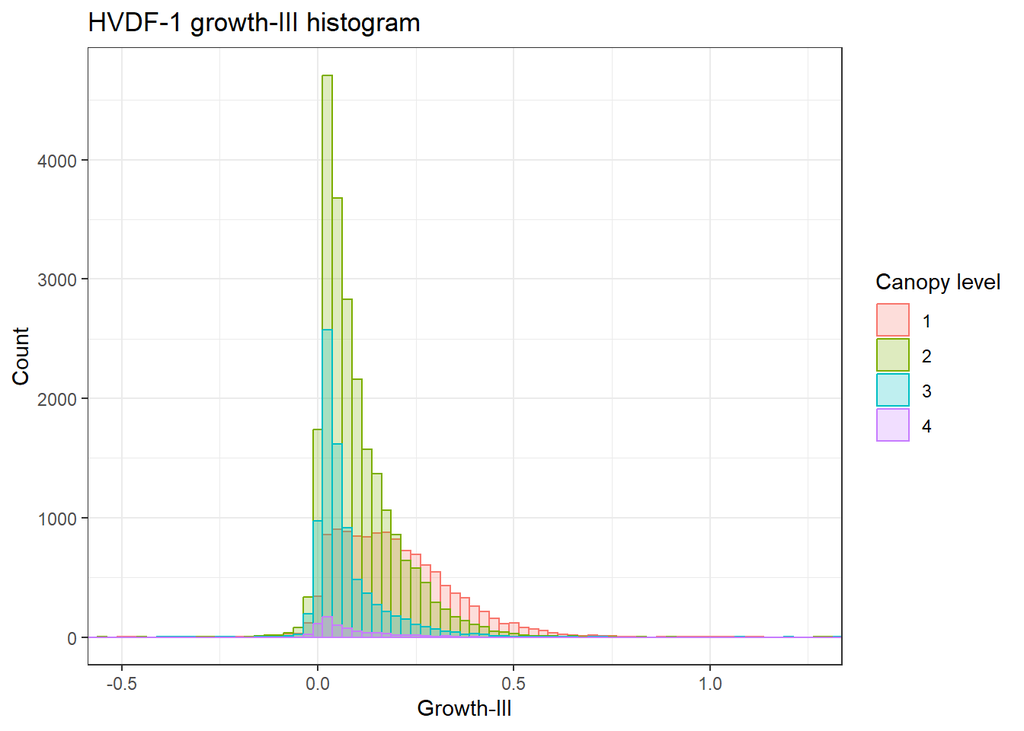

|  | growth1 | growth2 | growth3 |
| --- | --- | --- | --- |
| 0% | -5.59 | 0.67 | -4.75 |
| 0.1% | -0.41 | 0.96 | -0.39 |
| 0.2% | -0.15 | 0.98 | -0.15 |
| 0.5% | -0.06 | 0.99 | -0.06 |
| 1% | -0.03 | 0.99 | -0.03 |
| 5% | 0.00 | 1.00 | 0.00 |
| 25% | 0.03 | 1.00 | 0.03 |
| 50% | 0.07 | 1.01 | 0.08 |
| 75% | 0.17 | 1.02 | 0.18 |
| 95% | 0.35 | 1.06 | 0.35 |
| 99% | 0.50 | 1.10 | 0.52 |
| 99.5% | 0.57 | 1.13 | 0.59 |
| 99.8% | 0.73 | 1.15 | 0.76 |
| 99.9% | 1.20 | 1.17 | 1.38 |
| 100% | 4.02 | 1.46 | 7.22 |

Just looking at these distributions, it appears that removal of the most extreme values (the extreme 0.2% perhaps) should go a long way to remove messy observations.

Now lets break these up to the 5 most common OTUs. We are going to fit distributions to both of these growth parameters to the top 10 most common (only 5 were plotted for clarity).

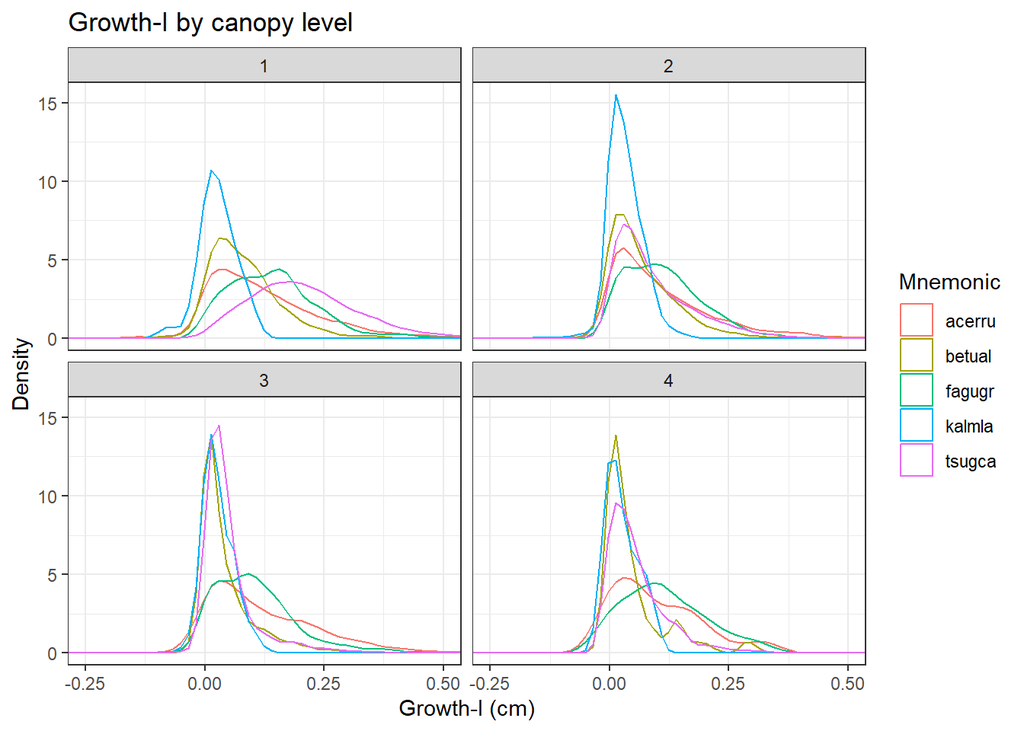

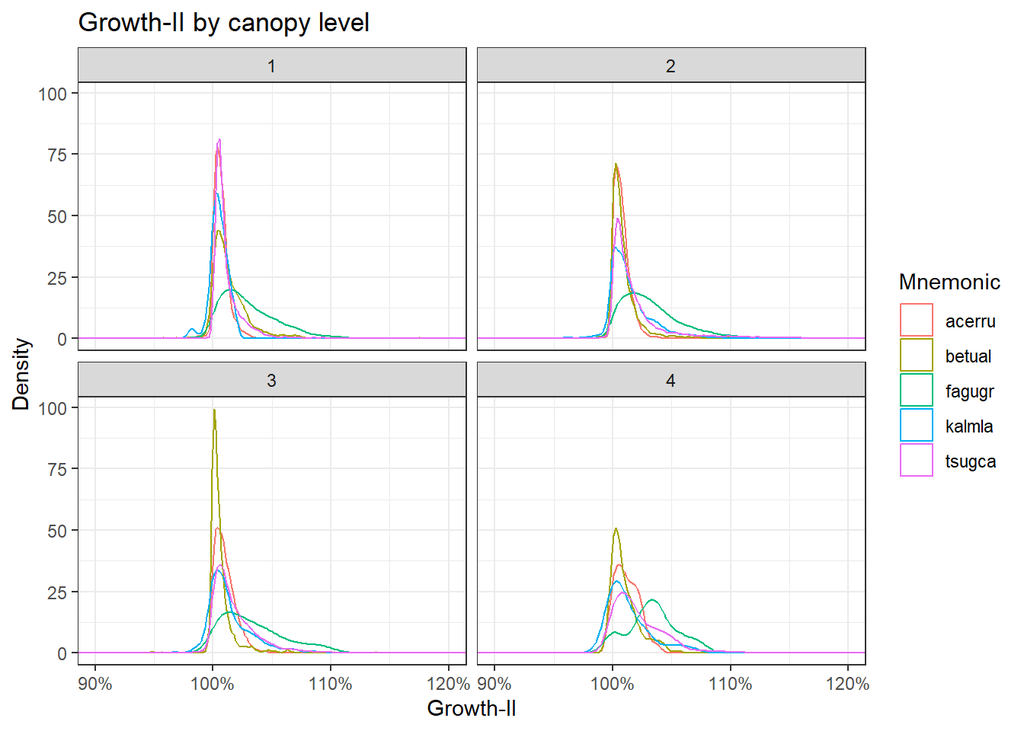

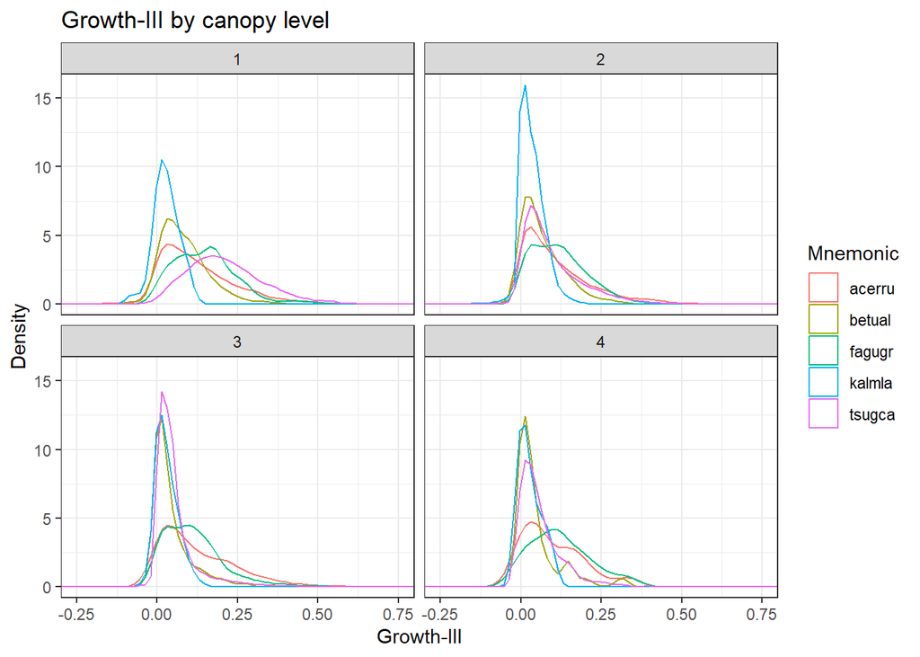

One thing to note between both these individual species and across all stems, is that growth (of all metrics) needs to be skewed right

To complement the visualization, here are a few key points for each OTU. The “Stems with growth” column is the percentage of stems that have growth values calculated. Stems can lack a value for their growth calculation for reasons such as change in the point of measurement, death of the stem, and not being the main stem of the plant. The “Growth >0” and “Growth >=0” columns are the percentage of growing stems that have growth of >0 or >=0 over the time frame.

| Mnemonic | Stems with growth | Growth >0 | Growth >=0 |
| --- | --- | --- | --- |
| acerpe | 41.1 | 95.8 | 99.2 |
| acerru | 56.6 | 90.3 | 97.3 |
| acersa | 25.0 | 100.0 | 100.0 |
| alnuin | 33.3 | 100.0 | 100.0 |
| amella | 40.2 | 69.6 | 92.4 |
| betual | 58.1 | 83.1 | 96.2 |
| betule | 70.5 | 94.6 | 98.8 |
| betupa | 33.5 | 85.5 | 94.5 |
| betupo | 12.4 | 93.8 | 100.0 |
| castde | 26.8 | 99.7 | 100.0 |
| fagugr | 63.1 | 94.9 | 99.1 |
| franal | 0.0 | NaN | NaN |
| fraxam | 51.9 | 90.0 | 95.5 |
| fraxni | 51.2 | 95.5 | 100.0 |
| hamavi | 29.4 | 88.5 | 98.0 |
| ilexla | 0.0 | NaN | NaN |
| ilexmu | 10.0 | 79.2 | 100.0 |
| ilexve | 22.5 | 75.3 | 97.0 |
| kalmla | 54.7 | 75.9 | 94.5 |
| lindbe | 16.9 | 81.0 | 95.2 |
| lyonli | 30.4 | 76.5 | 100.0 |
| nysssy | 84.6 | 92.4 | 97.0 |
| ostrvi | 71.4 | 75.0 | 95.0 |
| piceab | 16.9 | 75.5 | 91.7 |
| piceru | 51.4 | 77.0 | 90.5 |
| pinure | 56.0 | 72.0 | 84.3 |
| pinust | 46.7 | 95.5 | 98.0 |
| popugr | 100.0 | 100.0 | 100.0 |
| poputr | 0.0 | NaN | NaN |
| prunpe | 0.0 | NaN | NaN |
| prunse | 34.1 | 94.0 | 97.0 |
| queral | 56.2 | 100.0 | 100.0 |
| querru | 69.4 | 99.3 | 99.7 |
| querve | 74.7 | 99.4 | 99.4 |
| rhodpr | 13.2 | 61.9 | 85.7 |
| sambra | 0.0 | NaN | NaN |
| sorbam | 34.1 | 90.0 | 100.0 |
| tsugca | 67.7 | 93.5 | 98.7 |
| ulmuam | 100.0 | 100.0 | 100.0 |
| vaccco | 20.6 | 63.2 | 90.7 |
| vibuac | 0.0 | NaN | NaN |
| vibude | 0.0 | NaN | NaN |
| vibula | 20.8 | 70.8 | 93.8 |
| vibunu | 1.8 | 83.9 | 93.5 |

```
## [1] "Percentage of stems with growth values that have >0 growth: 90.7"
```

```
## [1] "Percentage of stems with growth values that have >=0 growth: 97.7"
```

And here is a breakdown of the number of stems for each of the most common taxa that have growth measures. I think this reinforces the point that level 4 needs the axe. Note that Viburnum nudum although a very common stem, doesn’t have many distinct growth measures since most stems would be in multi-stemmed plants.

| Mnemonic | n_Lvl1 | n_Lvl2 | n_Lvl3 | n_Lvl4 |
| --- | --- | --- | --- | --- |
| acerru | 1704 | 4151 | 953 | 78 |
| betual | 534 | 1366 | 800 | 127 |
| fagugr | 646 | 2149 | 386 | 59 |
| hamavi | 267 | 667 | 133 | 7 |
| kalmla | 29 | 2502 | 500 | 31 |
| pinust | 1129 | 138 | 5 | 1 |
| querru | 2117 | 1025 | 115 | 6 |
| tsugca | 4713 | 9041 | 4686 | 326 |
| vaccco | 62 | 241 | 107 | 8 |
| vibunu | 6 | 17 | 8 | 0 |